# Employee Data

Josephine Haag

2020-09-16

# 1 IBM HR Analytics

```r
hr_cleaned <- hr_dataset %>%
  clean_names() %>%
  mutate(
    education = case_when(
      education == 1 ~ "Below College",
      education == 2 ~ "College",
      education == 3 ~ "Bachelor",
      education == 4 ~ "Master",
      education == 5 ~ "Doctor"
    ),
    environment_satisfaction = case_when(
      environment_satisfaction == 1 ~ "Low",
      environment_satisfaction == 2 ~ "Medium",
      environment_satisfaction == 3 ~ "High",
      environment_satisfaction == 4 ~ "Very High"
    ),
    job_satisfaction = case_when(
      job_satisfaction == 1 ~ "Low",
      job_satisfaction == 2 ~ "Medium",
      job_satisfaction == 3 ~ "High",
      job_satisfaction == 4 ~ "Very High"
    ),
    performance_rating = case_when(
      performance_rating == 1 ~ "Low",
      performance_rating == 2 ~ "Good",
      performance_rating == 3 ~ "Excellent",
      performance_rating == 4 ~ "Outstanding"
    ),
    work_life_balance = case_when(
      work_life_balance == 1 ~ "Bad",
      work_life_balance == 2 ~ "Good",
      work_life_balance == 3 ~ "Better",
      work_life_balance == 4 ~ "Best"
    )
  ) %>%
  select(age, attrition, daily_rate, department,
         distance_from_home, education,
         gender, job_role,environment_satisfaction,
         job_satisfaction, marital_status,
         monthly_income, num_companies_worked, percent_salary_hike,
         performance_rating, total_working_years,
         work_life_balance, years_at_company,
         years_since_last_promotion)
```

1. How often do people leave the company (`attrition`)

```r
glimpse(hr_cleaned)
```

```
## Rows: 1,470
## Columns: 19
## $ age                        <dbl> 41, 49, 37, 33, 27, 32, 59, 30, 38, 36, 35…
## $ attrition                  <chr> "Yes", "No", "Yes", "No", "No", "No", "No"…
## $ daily_rate                 <dbl> 1102, 279, 1373, 1392, 591, 1005, 1324, 13…
## $ department                 <chr> "Sales", "Research & Development", "Resear…
## $ distance_from_home         <dbl> 1, 8, 2, 3, 2, 2, 3, 24, 23, 27, 16, 15, 2…
## $ education                  <chr> "College", "Below College", "College", "Ma…
## $ gender                     <chr> "Female", "Male", "Male", "Female", "Male"…
## $ job_role                   <chr> "Sales Executive", "Research Scientist", "…
## $ environment_satisfaction   <chr> "Medium", "High", "Very High", "Very High"…
## $ job_satisfaction           <chr> "Very High", "Medium", "High", "High", "Me…
## $ marital_status             <chr> "Single", "Married", "Single", "Married", …
## $ monthly_income             <dbl> 5993, 5130, 2090, 2909, 3468, 3068, 2670, …
## $ num_companies_worked       <dbl> 8, 1, 6, 1, 9, 0, 4, 1, 0, 6, 0, 0, 1, 0, …
## $ percent_salary_hike        <dbl> 11, 23, 15, 11, 12, 13, 20, 22, 21, 13, 13…
## $ performance_rating         <chr> "Excellent", "Outstanding", "Excellent", "…
## $ total_working_years        <dbl> 8, 10, 7, 8, 6, 8, 12, 1, 10, 17, 6, 10, 5…
## $ work_life_balance          <chr> "Bad", "Better", "Better", "Better", "Bett…
## $ years_at_company           <dbl> 6, 10, 0, 8, 2, 7, 1, 1, 9, 7, 5, 9, 5, 2,…
## $ years_since_last_promotion <dbl> 0, 1, 0, 3, 2, 3, 0, 0, 1, 7, 0, 0, 4, 1, …
```

```r
attrition_rate <- filter(hr_cleaned %>%
         group_by(attrition) %>%
         summarise(n = count(attrition)) %>%
         mutate(attrition_rate = (n*100)/sum(n)), attrition == "Yes") #added column for the attrition rate %

attrition_rate
```

```
## # A tibble: 1 x 3
##   attrition     n attrition_rate
##   <chr>     <int>          <dbl>
## 1 Yes         237           16.1
```

Answer: The attrition rate is 16.1%.

2. How are `age`, `years_at_company`, `monthly_income` and `years_since_last_promotion` distributed? can you roughly guess which of these variables is closer to Normal just by looking at summary statistics?

```r
skim(hr_cleaned)
```

Data summary

| Name | hr_cleaned |
| --- | --- |
| Number of rows | 1470 |
| Number of columns | 19 |
| _______________________ |  |
| Column type frequency: |  |
| character | 10 |
| numeric | 9 |
| ________________________ |  |
| Group variables | None |

**Variable type: character**

| skim_variable | n_missing | complete_rate | min | max | empty | n_unique | whitespace |
| --- | --- | --- | --- | --- | --- | --- | --- |
| attrition | 0 | 1 | 2 | 3 | 0 | 2 | 0 |
| department | 0 | 1 | 5 | 22 | 0 | 3 | 0 |
| education | 0 | 1 | 6 | 13 | 0 | 5 | 0 |
| gender | 0 | 1 | 4 | 6 | 0 | 2 | 0 |
| job_role | 0 | 1 | 7 | 25 | 0 | 9 | 0 |
| environment_satisfaction | 0 | 1 | 3 | 9 | 0 | 4 | 0 |
| job_satisfaction | 0 | 1 | 3 | 9 | 0 | 4 | 0 |
| marital_status | 0 | 1 | 6 | 8 | 0 | 3 | 0 |
| performance_rating | 0 | 1 | 9 | 11 | 0 | 2 | 0 |
| work_life_balance | 0 | 1 | 3 | 6 | 0 | 4 | 0 |

**Variable type: numeric**

| skim_variable | n_missing | complete_rate | mean | sd | p0 | p25 | p50 | p75 | p100 | hist |
| --- | --- | --- | --- | --- | --- | --- | --- | --- | --- | --- |
| age | 0 | 1 | 36.92 | 9.14 | 18 | 30 | 36 | 43 | 60 | ▂▇▇▃▂ |
| daily_rate | 0 | 1 | 802.49 | 403.51 | 102 | 465 | 802 | 1157 | 1499 | ▇▇▇▇▇ |
| distance_from_home | 0 | 1 | 9.19 | 8.11 | 1 | 2 | 7 | 14 | 29 | ▇▅▂▂▂ |
| monthly_income | 0 | 1 | 6502.93 | 4707.96 | 1009 | 2911 | 4919 | 8379 | 19999 | ▇▅▂▁▂ |
| num_companies_worked | 0 | 1 | 2.69 | 2.50 | 0 | 1 | 2 | 4 | 9 | ▇▃▂▂▁ |
| percent_salary_hike | 0 | 1 | 15.21 | 3.66 | 11 | 12 | 14 | 18 | 25 | ▇▅▃▂▁ |
| total_working_years | 0 | 1 | 11.28 | 7.78 | 0 | 6 | 10 | 15 | 40 | ▇▇▂▁▁ |
| years_at_company | 0 | 1 | 7.01 | 6.13 | 0 | 3 | 5 | 9 | 40 | ▇▂▁▁▁ |
| years_since_last_promotion | 0 | 1 | 2.19 | 3.22 | 0 | 0 | 1 | 3 | 15 | ▇▁▁▁▁ |

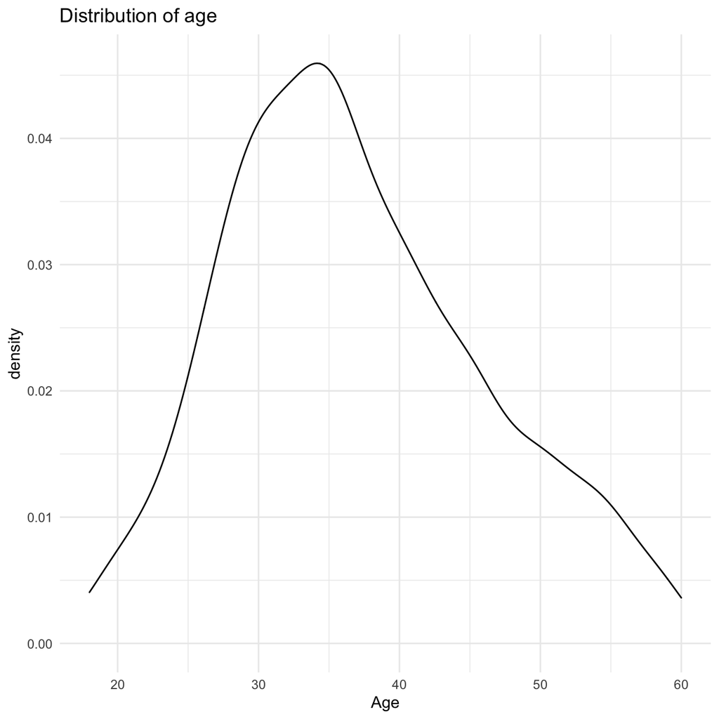

```r
age_density <- ggplot(hr_cleaned, aes(age)) +
  geom_density() +
  labs(
    title = "Distribution of age",
    x = "Age"
  ) +
  theme_minimal() +
  NULL

years_at_company_density <- ggplot(hr_cleaned, aes(years_at_company)) +
  geom_density() +
  labs(
    title = "Distribution of years at company",
    x = "Years at company"
  ) +
  theme_minimal() +
  NULL

monthly_income_density <-ggplot(hr_cleaned, aes(monthly_income)) +
  geom_density() +
  labs(
    title = "Distribution of monthly income",
    x = "Monthly income"
  ) +
  theme_minimal() +
  NULL

years_since_promotion <- ggplot(hr_cleaned, aes(years_since_last_promotion)) +
  geom_density() +
  labs(
    title = "Distribution of years since promotion",
    x = "Years since promotion"
  ) +
  theme_minimal() +
  NULL

age_density
```

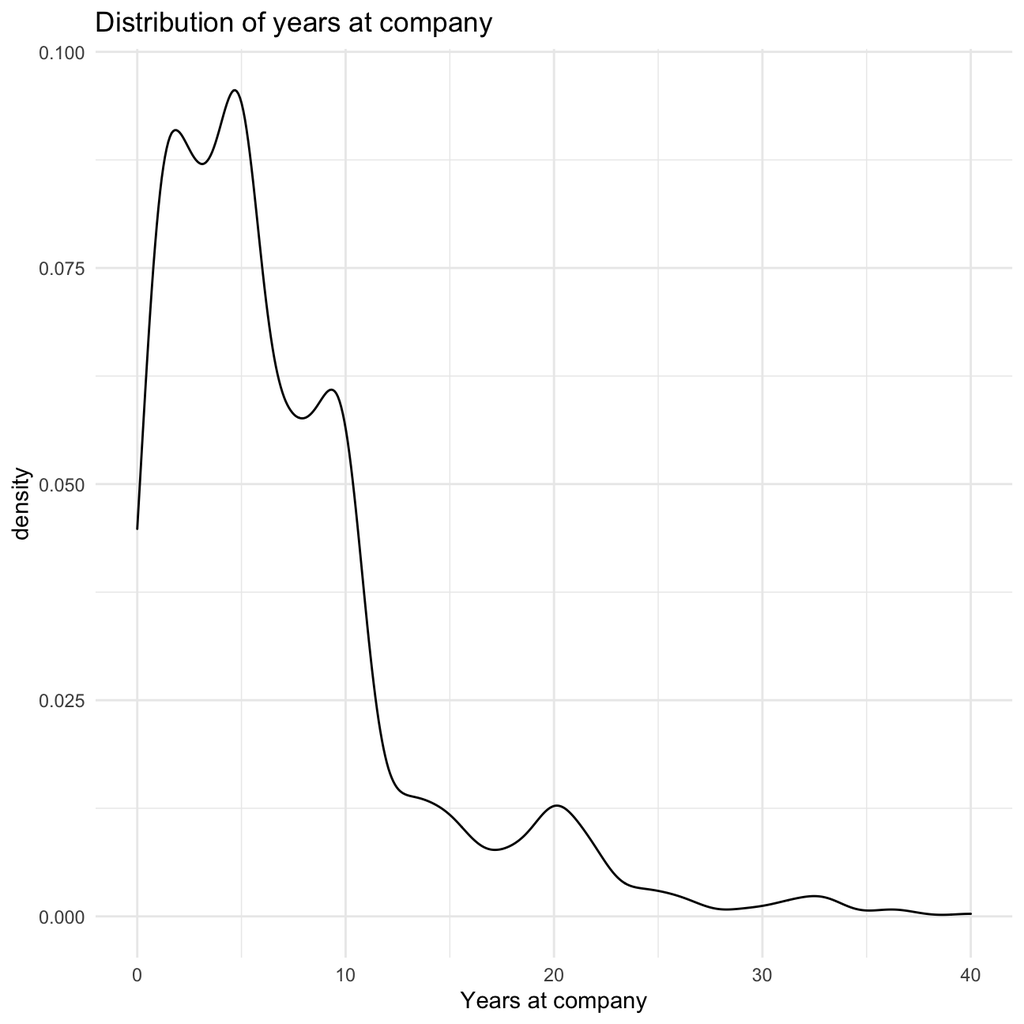

```r
years_at_company_density
```

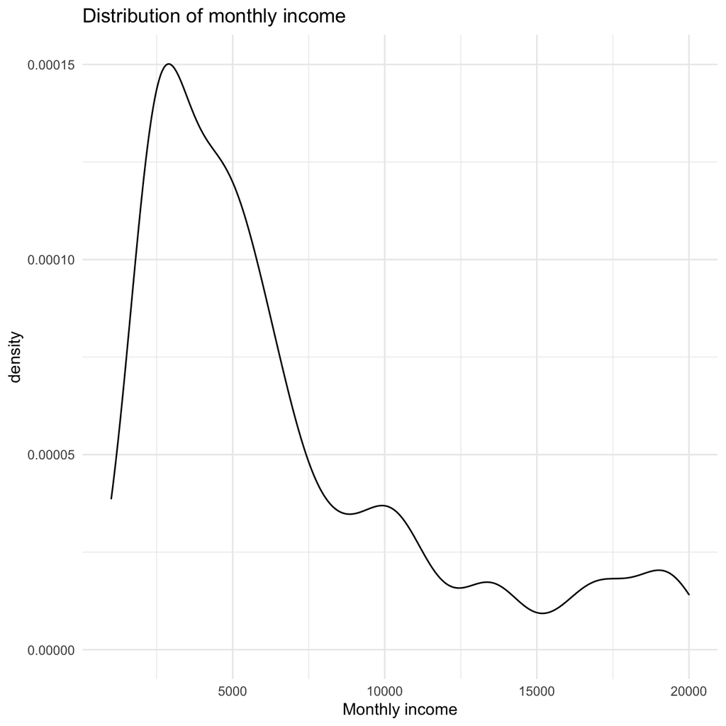

```r
monthly_income_density
```

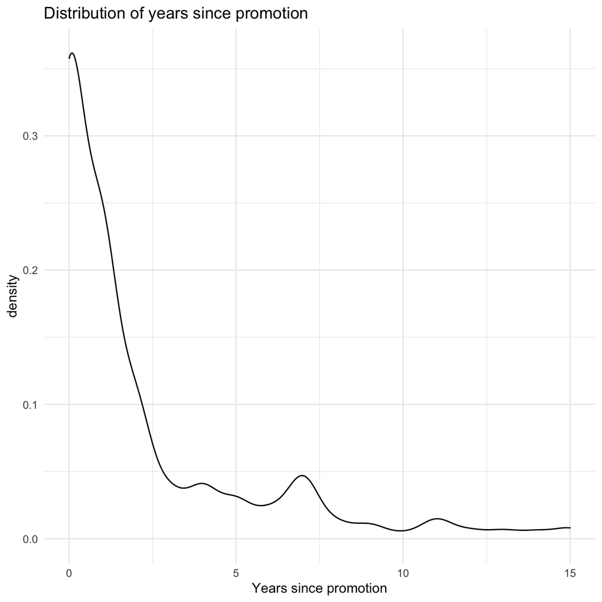

```r
years_since_promotion
```

Answer:

We can look at how close the mean is to the 50th percentile and the relative positions of 25th and 75th percentiles are to the 50th percentile.`age` is close to normal distribution, while `years_at_company`, `monthly_income` and `years_since_last_promotion` are right screwed, with most small values in the left hand, a few large values in the right.

3. How are `job_satisfaction` and `work_life_balance` distributed? Don’t just report counts, but express categories as % of total

```r
job_sat <- hr_cleaned %>%
  group_by(job_satisfaction) %>%
  summarise(n = count(job_satisfaction)) %>%
  mutate(job_sat_perc = (n*100)/sum(n))

work_life_balance <- hr_cleaned %>%
  group_by(work_life_balance) %>%
  summarise(n = count(work_life_balance)) %>%
  mutate(work_life_perc = (n*100)/sum(n)) %>%
  arrange(desc(work_life_perc))
#
# kbl(job_sat) %>%
#   kable_styling(bootstrap_options=c("striped","hover","condensed","responsive"))
# kbl(work_life_balance) %>%
#   kable_styling(bootstrap_options=c("striped","hover","condensed","responsive"))
```

4. Is there any relationship between monthly income and education? Monthly income and gender?

[figure not shown]

```r
library(hrbrthemes)
options("scipen"=100, "digits"=4)

monthly_income_education_plot <- ggplot(hr_cleaned,
   aes(
     x = education,
     y = monthly_income
   )) +
  geom_col() +
  theme_minimal() +
  theme(text = element_text(size=40))+
  labs(
    title = "Monthly income vs. education",
    x = "Monthly income",
    y = "Education"
  ) +
  NULL

monthly_income_gender_plot <- ggplot(hr_cleaned,
   aes(
     x = gender,
     y = monthly_income
   )) +
  geom_col() +
  theme_minimal() +
  theme(text = element_text(size=30))+
  labs(
    title = "Monthly income vs. gender",
    x = "Monthly income",
    y = "Gender"
  ) +
  NULL

monthly_income_education_plot
```

[figure not shown]

```r
monthly_income_gender_plot
```

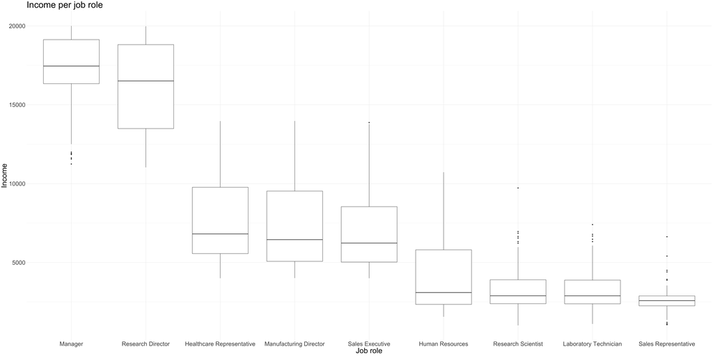

```r
income_jobrole_boxplot <- ggplot(hr_cleaned,
       aes(
         x= reorder(job_role, -monthly_income),
         y = monthly_income)) +
  geom_boxplot() +
  labs(
    title = "Income per job role",
    x = "Job role",
    y = "Income"
  ) +
  theme_minimal() +
  theme(text = element_text(size=30))+
  NULL

income_jobrole_boxplot
```

6. Calculate and plot a bar chart of the mean (or median?) income by education level.

[figure not shown]

```r
Education_mean_income_bar <- ggplot(hr_cleaned, aes(
    x = education,
    y = mean(monthly_income
    ))) +
  geom_col() +
  labs(
    title = "Mean monthly income per education",
    x = "Education",
    y = "Mean monthly income"
  ) +
  theme_minimal() +
  theme(text = element_text(size=10))+
  NULL

Education_median_income_bar <- ggplot(hr_cleaned, aes(
    x = education,
    y = median(monthly_income
    ))) +
  geom_col() +
  labs(
    title = "Median monthly income per education",
    x = "Education",
    y = "Median monthly income") +
  theme_minimal() +
  theme(text = element_text(size=10))+
  NULL

Education_mean_income_bar
```

[figure not shown]

```r
Education_median_income_bar
```

7. Plot the distribution of income by education level. Use a facet_wrap and a theme from `ggthemes`

[figure not shown]

```r
Monthly_income_education_distr <- ggplot(hr_cleaned, aes(
    x = monthly_income
  )) +
  geom_histogram() +
  facet_wrap(~education,ncol=2) +
  labs(
    title = "Distribution of income by education",
    x = "Education"
  ) +
  theme_economist_white() +
  NULL

Monthly_income_education_distr
```

1. Plot income vs age, faceted by `job_role`

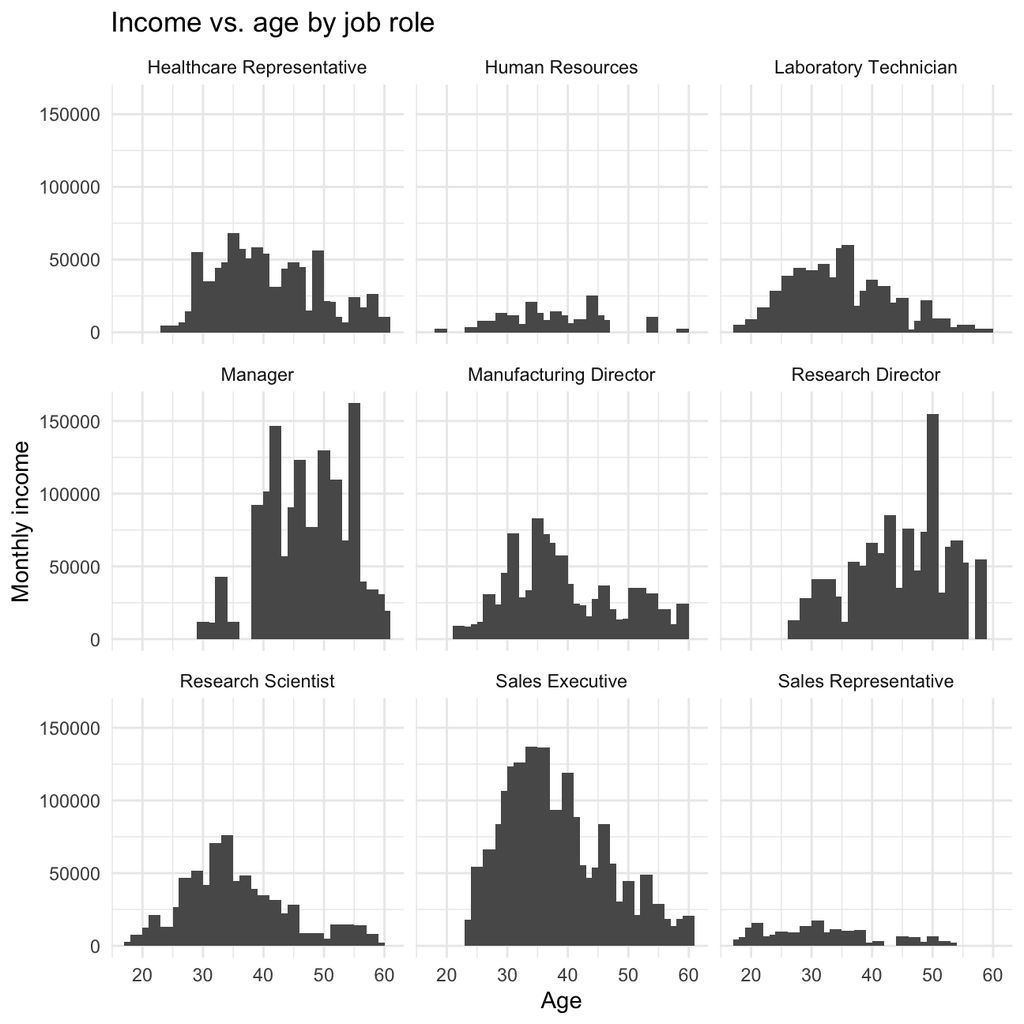

```r
Income_vs_age_facet <- ggplot(hr_cleaned, aes(
    x = age,
    y = monthly_income
  )) +
  geom_col(width = 2) +
  facet_wrap(~job_role) +
  labs(
    title = "Income vs. age by job role",
    x = "Age",
    y = "Monthly income"
  ) +
  theme_minimal() +
  NULL

Income_vs_age_facet
```